# Webscraping Text with `rvest`

Webscraping Text with `rvest`

Author

Affiliation

Emily Malcolm-White

Middlebury College

[figure not shown]

```r
#LOAD PACKAGES
library(tidyverse)
library(rvest)
```

# Webscraping Text

Let’s look at the [top 50 feature films in the first 7 months of 2023 listed on IMBD](https://www.imdb.com/search/title/?title_type=feature&year=2023-01-01,2023-07-31)

```r
URL <- read_html("https://www.imdb.com/search/title/?title_type=feature&year=2023-01-01,2023-07-31")
```

Notice that the data for all these films isn’t housed inside a `<table>` element!

## Titles

For example, check out the first few lines of html code for Oppenheimer:

```
<h3 class="lister-item-header">
        <span class="lister-item-index unbold text-primary">1.</span>
    <a href="/title/tt15398776/?ref_=adv_li_tt"
>Oppenheimer</a>
    <span class="lister-item-year text-muted unbold">(2023)</span>
</h3>
```

In this case, we want to look for the class `lister-item-header` AND then pull the text inside the `<a>` (link) tag.

`html_elements(".lister-item-header a")`

**Tip**

In this case, we want ALL titles so we used `html_elements()`. If we had only wanted the first title we would have used `html_element()`

Scrape IMBD for the titles of the 50 most popular feature films in the first 7 months of 2023.

```r
# title_data <- URL %>%
#   html_elements(".lister-item-header a") %>%
#   html_text()
#
# title_data
```

## Runtime

Scrape IMBD for the runtime of the 50 most popular feature films so far in 2023.

Check out the relevant HTML code for Oppenheimer:

```
    <p class="text-muted ">
            <span class="certificate">R</span>
                 <span class="ghost">|</span>
                 <span class="runtime">180 min</span>
                 <span class="ghost">|</span>
            <span class="genre">
Biography, Drama, History            </span>
    </p>
```

In this case, we need to reference the class `text-muted` AND the class `runtime`.

```r
# URL %>%
#   html_nodes(".text-muted .runtime") %>%
#   html_text()
```

Alternatively, we could have called class `text-muted` AND the 3rd span, but it’s easier and likely more accurate to ask for the class `runtime` in case `runtime` is missing for some reason.

Maybe we want to keep the `min` on the end, but it forces it into being a stringr rather than a number which makes it difficult to sort or filter.

```r
library(readr)
# need this package for parse_number()
```

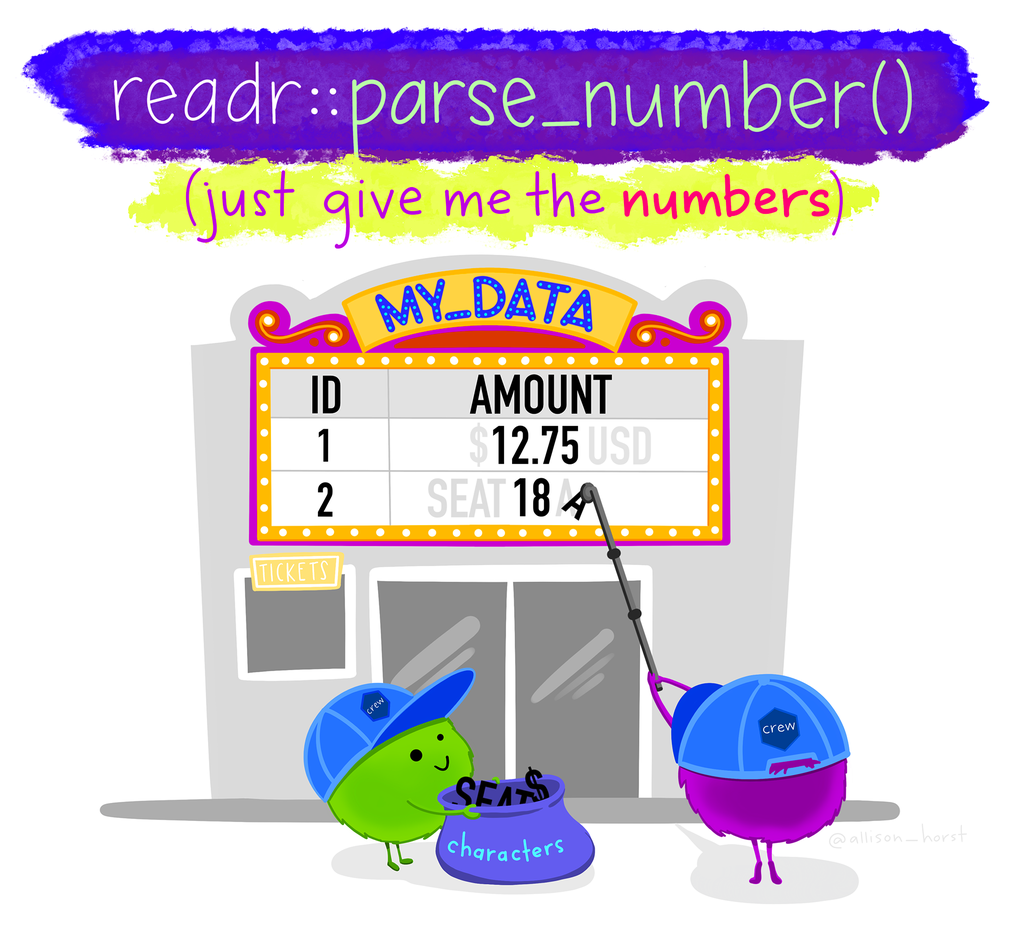

Artwork by @allisonhorst

```r
# runtime_data <- URL %>%
#   html_nodes(".text-muted .runtime") %>%
#   html_text() %>%
#   parse_number() %>% #this picks out only the numbers (and drops characters, in this case, "mins")
#   as.numeric()
#
# runtime_data
```

## Ratings

Scrape IMBD for the ratings of the 50 most popular feature films in the first 7 months of 2023.

Check out the relevant HTML code for Oppenheimer:

```
    <div class="inline-block ratings-imdb-rating" name="ir" data-value="8.6">
        <span class="global-sprite rating-star imdb-rating"></span>
        <strong>8.6</strong>
    </div>
```

Let’s scrape it!

```r
# rating_data <- URL %>%
#   html_elements(".ratings-imdb-rating strong") %>%
#   html_text() %>%
#   as.numeric()
#
# rating_data
```

**Warning**

Once we figure out which one is it is, we should should add a blank element for the rating for that movie using the `append` function.

It’s Killers of the Flower Moon (#32)!

```r
#rating_data <- append(rating_data, values=NA, after=31)
```

## Number of Votes

Scrape IMBD for the number of votes of the 50 most popular feature films in the first 7 months of 2023.

Relevant code for Oppenheimer:

```
        <p class="sort-num_votes-visible">
                <span class="text-muted">Votes:</span>
                <span name="nv" data-value="391689">391,689</span>
        </p>
```

Let’s scrape it!

```r
# votes_data <- URL %>%
#   html_elements(".sort-num_votes-visible span:nth-child(2)") %>%
#   html_text() %>%
#   parse_number() %>%
#   as.numeric()
#
# votes_data
```

**Warning**

```r
#votes_data <- append(votes_data, values=NA, after=31)
```

## Metascore

Relevant code for Oppenheimer:

```
            <div class="inline-block ratings-metascore">
<span class="metascore  favorable">88        </span>
        Metascore
            </div>
```

Let’s scrape it!

```r
# metascore_data <- URL %>%
#   html_elements(".metascore") %>%
#   html_text() %>%
#   parse_number() %>%
#   as.numeric()
#
# metascore_data
```

**Warning**

# Combining it all together into a data frame!

We can combine all this data into one data frame:

```r
# movies <- data.frame(Title = title_data,
# Runtime = runtime_data,
# Rating = rating_data,
# Votes = votes_data
# )
#
# movies
```

Make a list OR Make a plot!

```r
# ggplot(movies, aes(x=runtime_data, y=rating_data)) +
#   geom_point() +
#   theme_minimal() +
#   xlab("Runtime (in minutes)") +
#   ylab("IMDB Rating")
```